# Chapter 5 Seminar: VAR Models & Granger Causality - Practice Exercises

## Exercise 7: Forecasting with VAR

### Task

Generate multi-step forecasts with confidence intervals.

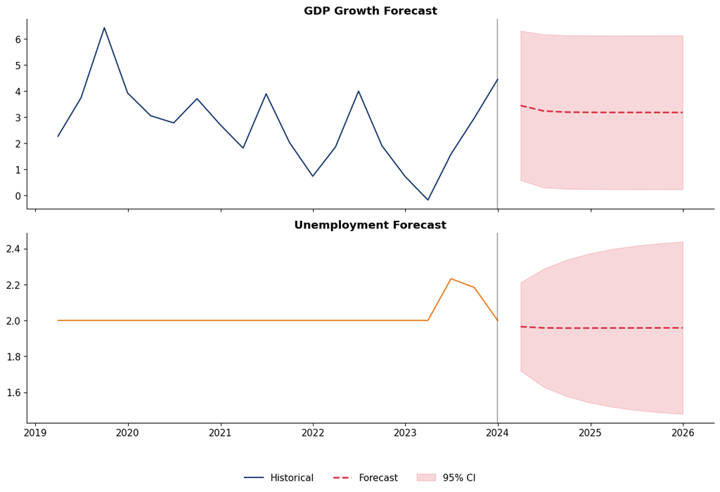

```python
# Generate forecasts
forecast_steps = 8  # 2 years
lag_order_used = macro_results.k_ar  # Get actual lag order from fitted model
forecast = macro_results.forecast(macro_data.values[-lag_order_used:], steps=forecast_steps)

# Create forecast dates
forecast_dates = pd.date_range(start=macro_data.index[-1] + pd.DateOffset(months=3),
                               periods=forecast_steps, freq='QE')

# Get forecast intervals
forecast_interval = macro_results.forecast_interval(macro_data.values[-lag_order_used:],
                                                     steps=forecast_steps, alpha=0.05)

# Plot
fig, axes = plt.subplots(2, 1, figsize=(12, 8), sharex=True)

# GDP Growth
axes[0].plot(macro_data.index[-20:], macro_data['GDP_Growth'].values[-20:],
             color=COLORS['blue'], linewidth=1.5, label='Historical')
axes[0].plot(forecast_dates, forecast[:, 0],
             color=COLORS['red'], linewidth=2, linestyle='--', label='Forecast')
axes[0].fill_between(forecast_dates, forecast_interval[1][:, 0], forecast_interval[2][:, 0],
                     color=COLORS['red'], alpha=0.2, label='95% CI')
axes[0].axvline(x=macro_data.index[-1], color='black', linestyle='-', alpha=0.3)
axes[0].set_title('GDP Growth Forecast', fontweight='bold')

# Unemployment
axes[1].plot(macro_data.index[-20:], macro_data['Unemployment'].values[-20:],
             color=COLORS['orange'], linewidth=1.5, label='Historical')
axes[1].plot(forecast_dates, forecast[:, 1],
             color=COLORS['red'], linewidth=2, linestyle='--', label='Forecast')
axes[1].fill_between(forecast_dates, forecast_interval[1][:, 1], forecast_interval[2][:, 1],
                     color=COLORS['red'], alpha=0.2, label='95% CI')
axes[1].axvline(x=macro_data.index[-1], color='black', linestyle='-', alpha=0.3)
axes[1].set_title('Unemployment Forecast', fontweight='bold')

# Legend outside at bottom
handles, labels = axes[0].get_legend_handles_labels()
fig.legend(handles, labels, loc='lower center', ncol=3, bbox_to_anchor=(0.5, -0.02))

plt.tight_layout()
plt.subplots_adjust(bottom=0.12)
plt.show()
```

```python
# Print forecast table
print("Forecast Summary:")
print("="*70)
print(f"{'Date':<12} {'GDP Growth':>15} {'95% CI':>20} {'Unemp':>10} {'95% CI':>20}")
for i in range(forecast_steps):
    print(f"{str(forecast_dates[i].date()):<12} {forecast[i, 0]:>15.2f} "
          f"[{forecast_interval[1][i, 0]:>6.2f}, {forecast_interval[2][i, 0]:>6.2f}] "
          f"{forecast[i, 1]:>10.2f} [{forecast_interval[1][i, 1]:>6.2f}, {forecast_interval[2][i, 1]:>6.2f}]")
```

```
Forecast Summary:
======================================================================
Date              GDP Growth               95% CI      Unemp               95% CI
2024-03-31              3.44 [  0.57,   6.30]       1.97 [  1.72,   2.21]
2024-06-30              3.23 [  0.29,   6.16]       1.96 [  1.63,   2.29]
2024-09-30              3.18 [  0.24,   6.13]       1.96 [  1.58,   2.34]
2024-12-31              3.17 [  0.23,   6.12]       1.96 [  1.54,   2.37]
2025-03-31              3.17 [  0.23,   6.12]       1.96 [  1.52,   2.40]
2025-06-30              3.17 [  0.22,   6.12]       1.96 [  1.50,   2.42]
2025-09-30              3.17 [  0.22,   6.12]       1.96 [  1.49,   2.43]
2025-12-31              3.17 [  0.22,   6.12]       1.96 [  1.48,   2.44]
```

## Summary

### What We Practiced

1. **VAR Model Structure**: Understanding coefficient matrices and parameter counting
2. **Estimation**: Fitting VAR models and selecting lag order
3. **Granger Causality**: Testing predictive relationships between variables
4. **Impulse Response Functions**: Tracing shock propagation
5. **FEVD**: Decomposing forecast variance by shock source
6. **Forecasting**: Multi-step predictions with uncertainty

### Key Takeaways

- VAR models capture interdependencies between multiple time series
- Granger causality tests predictive content, NOT true causation
- Stability requires eigenvalues inside the unit circle
- IRF and FEVD depend on shock ordering (Cholesky identification)
- Always check stationarity before estimating VAR
- Use BIC for parsimonious model selection